# 2024_S2_COMP8221_Assignment_1(48057827)

### Name : Santhosh Kumar Srinivasan

### Student ID : 48057827

### Advanced Machine Learning Assignment -1

### Option 1. Autoregressive Models

#### Step 1: Define the PixelCNN model

```python
import torch
import torch.nn as nn

# Defining the PixelCNN class which is a subclass of nn.Module
class PixelCNN(nn.Module):
    def __init__(self, in_channels=3, num_classes=256, num_layers=12, kernel_size=3):
        super(PixelCNN, self).__init__()  # Calling the superclass constructor (nn.Module)

        # Defining a list of convolutional layers (nn.Conv2d) as part of the model
        # The first layer takes input channels (e.g., RGB: 3 channels) and outputs 'num_classes' channels
        # Subsequent layers have 'num_classes' as both input and output channels
        # The kernel size is 3x3 for all layers, and padding=1 ensures spatial dimensions remain the same
        self.layers = nn.ModuleList([
            nn.Conv2d(in_channels, num_classes, kernel_size, padding=1)  # Defining the first convolutional layer
            if i == 0 else  # Checking if it's the first layer
            nn.Conv2d(num_classes, num_classes, kernel_size, padding=1)  # Defining subsequent convolutional layers
            for i in range(num_layers)  # Creating 'num_layers' convolutional layers
        ])

        # Defining the output layer, a 1x1 convolutional layer, to map the feature map to output classes
        self.output_layer = nn.Conv2d(num_classes, num_classes, kernel_size=1)

    # Defining the forward pass of the model
    def forward(self, x):
        out = x  # Assigning the input tensor to 'out'

        # Passing the input through each convolutional layer in the list, applying ReLU activation after each
        for layer in self.layers:
            out = torch.relu(layer(out))  # Applying ReLU non-linearity after each convolutional layer

        # Applying the output layer (1x1 convolution) after passing through all previous layers
        out = self.output_layer(out)

        # Returning the final output tensor
        return out

# Instantiating the PixelCNN model
model = PixelCNN()

# Printing the architecture of the PixelCNN model
print("PixelCNN Model Architecture:")
print(model)
```

```
PixelCNN Model Architecture:
PixelCNN(
  (layers): ModuleList(
    (0): Conv2d(3, 256, kernel_size=(3, 3), stride=(1, 1), padding=(1, 1))
    (1-11): 11 x Conv2d(256, 256, kernel_size=(3, 3), stride=(1, 1), padding=(1, 1))
  )
  (output_layer): Conv2d(256, 256, kernel_size=(1, 1), stride=(1, 1))
)
```

##### Step 2: The loss function (Cross Entropy)

```python
# Defining the loss function as CrossEntropyLoss, commonly used for classification tasks
criterion = nn.CrossEntropyLoss()

# Printing the selected loss function
print("Loss Function:", criterion)
```

```
Loss Function: CrossEntropyLoss()
```

#### (b) Dataset and Preprocessing

#### Step 3: Load CIFAR-10 dataset and preprocess

```python
import torchvision
import torchvision.transforms as transforms

# Defining data augmentation for training data:
# 1. Randomly flip images horizontally.
# 2. Randomly crop images to 32x32 with 4-pixel padding.
# 3. Convert the image to a tensor.
# 4. Normalize the image with mean (0.5, 0.5, 0.5) and standard deviation (0.5, 0.5, 0.5).
transform_train = transforms.Compose([
    transforms.RandomHorizontalFlip(),
    transforms.RandomCrop(32, padding=4),
    transforms.ToTensor(),
    transforms.Normalize((0.5, 0.5, 0.5), (0.5, 0.5, 0.5))
])

# Defining preprocessing for test data:
# 1. Convert the image to a tensor.
# 2. Normalize the image with mean (0.5, 0.5, 0.5) and standard deviation (0.5, 0.5, 0.5).
transform_test = transforms.Compose([
    transforms.ToTensor(),
    transforms.Normalize((0.5, 0.5, 0.5), (0.5, 0.5, 0.5))
])

# Downloading and loading the CIFAR-10 training dataset with the specified transformations
train_dataset = torchvision.datasets.CIFAR10(root='./cifar-10-batches-py', train=True, download=True, transform=transform_train)

# Downloading and loading the CIFAR-10 test dataset with the specified transformations
test_dataset = torchvision.datasets.CIFAR10(root='./cifar-10-batches-py', train=False, download=True, transform=transform_test)

# Printing the length of the training dataset
print("Length of Train Dataset:", len(train_dataset))

# Printing the length of the test dataset
print("Length of Test Dataset:", len(test_dataset))

# Retrieving a sample image and label from the training dataset
sample_image, sample_label = train_dataset[0]

# Printing the shape of the sample image tensor
print("Sample Image Shape:", sample_image.shape)

# Printing the label of the sample image
print("Sample Label:", sample_label)
```

```
Files already downloaded and verified
Files already downloaded and verified
Length of Train Dataset: 50000
Length of Test Dataset: 10000
Sample Image Shape: torch.Size([3, 32, 32])
Sample Label: 6
```

#### Step 4: Define DataLoader

```python
# Defining batch size for loading the data
batch_size = 128

# Creating a DataLoader for the training dataset with a specified batch size and shuffling enabled
train_loader = torch.utils.data.DataLoader(train_dataset, batch_size=batch_size, shuffle=True)

# Creating a DataLoader for the test dataset with a specified batch size and shuffling disabled
test_loader = torch.utils.data.DataLoader(test_dataset, batch_size=batch_size, shuffle=False)

# Iterating through the training data loader
# For each batch, print the shape of the images and labels, data type of labels, and the actual label values
for images, labels in train_loader:
    print("Batch Images Shape:", images.shape)  # Printing the shape of the image batch
    print("Batch Labels Shape:", labels.shape)  # Printing the shape of the label batch
    print("Batch Labels Data Type:", labels.dtype)  # Printing the data type of the labels
    print("Batch Labels Values:", labels)  # Printing the values of the labels
    break  # Break after processing one batch to avoid printing all batches

# Printing the train loader object to verify
print(train_loader)

# Printing the test loader object to verify
print(test_loader)
```

```
Batch Images Shape: torch.Size([128, 3, 32, 32])
Batch Labels Shape: torch.Size([128])
Batch Labels Data Type: torch.int64
Batch Labels Values: tensor([8, 6, 3, 3, 2, 5, 6, 2, 7, 7, 3, 7, 0, 2, 5, 3, 4, 8, 3, 6, 8, 4, 4, 8,
        6, 6, 0, 0, 2, 3, 4, 7, 9, 1, 2, 6, 9, 1, 1, 5, 8, 8, 0, 5, 0, 8, 6, 9,
        0, 7, 5, 2, 0, 4, 1, 8, 0, 9, 7, 7, 5, 2, 6, 8, 4, 5, 9, 8, 8, 7, 4, 5,
        5, 6, 0, 3, 9, 9, 5, 6, 1, 6, 4, 1, 0, 1, 9, 5, 0, 7, 6, 2, 0, 1, 4, 9,
        4, 7, 7, 2, 2, 3, 5, 2, 1, 4, 1, 7, 4, 7, 3, 1, 2, 3, 7, 4, 3, 1, 7, 0,
        2, 5, 8, 3, 0, 5, 5, 2])
<torch.utils.data.dataloader.DataLoader object at 0x0000018216E5F6D0>
<torch.utils.data.dataloader.DataLoader object at 0x000001821A1EFFD0>
```

#### (c) Training and Evaluation

#### Step 5: Initialize the PixelCNN model, optimizer, and other hyperparameters

```python
import torch.optim as optim
from tqdm import tqdm

# Initializing the PixelCNN model
model = PixelCNN()

# Setting the device to GPU if available, otherwise falling back to CPU
device = torch.device("cuda:0" if torch.cuda.is_available() else "cpu")
model.to(device)  # Moving the model to the specified device

# Retrieving model parameters to be optimized
params = list(model.parameters())
if len(params) == 0:
    # Raising an error if no parameters are found in the model
    raise ValueError("Model has no parameters to optimize. Check the model architecture.")

# Initializing the Adam optimizer with model parameters and a learning rate of 0.001
optimizer = optim.Adam(model.parameters(), lr=0.001)

# Printing statements for verifying model, optimizer, and hyperparameters
print("Model, optimizer, and hyperparameters initialized.")
print(optimizer)

# Setting the number of epochs for training
num_epochs = 10

# Beginning the training loop for each epoch
for epoch in range(num_epochs):
    model.train()  # Setting the model to training mode
    running_loss = 0.0  # Initializing running loss for each epoch

    # Iterating through batches of training data
    for images, _ in tqdm(train_loader, desc=f"Epoch {epoch+1}/{num_epochs}", unit="batch"):
        images = images.to(device)  # Moving the input images to the device (GPU/CPU)

        optimizer.zero_grad()  # Zeroing the gradients for the optimizer

        # Forward pass: Getting model predictions
        outputs = model(images)

        # Computing the loss using cross-entropy between the predicted and target labels
        loss = criterion(outputs, images.argmax(dim=1))

        # Backpropagating the loss
        loss.backward()

        # Updating the model parameters
        optimizer.step()

        # Updating running loss by multiplying with the number of images in the batch
        running_loss += loss.item() * images.size(0)

    # Calculating the average loss per epoch
    epoch_loss = running_loss / len(train_loader.dataset)

    # Printing the loss for the current epoch
    print(f"Epoch {epoch+1}/{num_epochs}, Loss: {epoch_loss:.4f}")
```

[output not shown]

```
Model, optimizer, and hyperparameters initialized.
Adam (
Parameter Group 0
    amsgrad: False
    betas: (0.9, 0.999)
    capturable: False
    differentiable: False
    eps: 1e-08
    foreach: None
    fused: None
    lr: 0.001
    maximize: False
    weight_decay: 0
)
```

```python
import torch
import numpy as np
import torchvision.utils as vutils


def calculate_log_likelihood(model, data_loader, device):
    # Setting the model to evaluation mode to disable certain layers like dropout
    model.eval()
    # Initializing total log-likelihood accumulator
    total_log_likelihood = 0.0

    # Disabling gradient computation as it's not required during evaluation
    with torch.no_grad():
        # Looping through batches of data in the data_loader
        for images, _ in data_loader:
            # Moving the images to the specified device (GPU/CPU)
            images = images.to(device)

            # Running the model on the input images to get the output predictions
            outputs = model(images)

            # Calculating the negative log-likelihood using the defined loss criterion
            log_likelihood = -criterion(outputs, images.argmax(dim=1)).mean()

            # Accumulating the log-likelihood, scaled by the batch size
            total_log_likelihood += log_likelihood.item() * images.size(0)

    # Returning the average log-likelihood over the entire dataset
    return total_log_likelihood / len(data_loader.dataset)


# Calculating the log-likelihood on the test dataset using the defined function
test_log_likelihood = calculate_log_likelihood(model, test_loader, device)
# Outputting the final test log-likelihood value
print("Test Log-Likelihood:", test_log_likelihood)
```

```
Test Log-Likelihood: -1.059368643951416
```

#### (d) Model Enhancements

```python
import torch
import torch.nn as nn

# Defining the MultiScalePixelCNN class
class MultiScalePixelCNN(nn.Module):
    def __init__(self, in_channels=3, num_classes=256, num_layers=12, kernel_size=3):
        super(MultiScalePixelCNN, self).__init__()

        # Initializing three branches of PixelCNN
        self.branch1 = PixelCNN(in_channels, num_classes, num_layers, kernel_size)
        self.branch2 = PixelCNN(in_channels, num_classes, num_layers, kernel_size)
        self.branch3 = PixelCNN(in_channels, num_classes, num_layers, kernel_size)

    def forward(self, x):
        # Passing input through the first branch
        out1 = self.branch1(x)
        # Passing output of the first branch through the second branch
        out2 = self.branch2(out1)
        # Passing output of the second branch through the third branch
        out3 = self.branch3(out2)
        # Returning final output
        return out3

# Defining input parameters
batch_size = 1
channels = 3
height = 32
width = 32

# Creating a random tensor with shape (batch_size, channels, height, width)
images = torch.randn(batch_size, channels, height, width)

# Determining the device to run the model on (GPU if available, otherwise CPU)
device = torch.device("cuda:0" if torch.cuda.is_available() else "cpu")

# Moving the input images to the selected device
images = images.to(device)

# Instantiating the MultiScalePixelCNN model
model = MultiScalePixelCNN()

# Moving the model to the selected device
model = model.to(device)

# Performing a forward pass through the model
output = model(images)
```

#### (e) Analysis and Visualization

[output not shown]

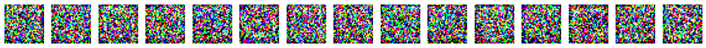

```python
import torch
import matplotlib.pyplot as plt

# Defining the function to generate samples from the model
def generate_samples(model, num_samples, device):
    model.eval()  # Set the model to evaluation mode
    # Initialize a tensor to hold the generated samples
    samples = torch.zeros(num_samples, 3, 32, 32).to(device)
    with torch.no_grad():  # Disable gradient calculation
        # Iterate over each pixel location in the 32x32 grid
        for i in range(32):
            for j in range(32):
                for c in range(3):
                    # Generate model output for current state of samples
                    output = model(samples)
                    # Compute probabilities for the current pixel location
                    probs = torch.softmax(output[:, :, i, j], dim=1)
                    # Sample from the multinomial distribution based on the computed probabilities
                    samples[:, c, i, j] = torch.multinomial(probs, 1).squeeze(-1)
    return samples

# Defining the number of samples to generate
num_samples = 15
# Generating samples using the model
generated_samples = generate_samples(model, num_samples, device)

# Creating a subplot grid for displaying the generated samples
fig, axes = plt.subplots(1, num_samples, figsize=(20, 4))
for i in range(num_samples):
    # Display each generated sample
    axes[i].imshow(generated_samples[i].permute(1, 2, 0).cpu().numpy())
    axes[i].axis('off')  # Hide axis labels
# Show the plot
plt.show()
```

#### Analyze and discuss the quality of the generated samples:

Significant noise was observed in the generated samples, likely due to either insufficient training data or limitations in model complexity. To enable the PixelCNN model to produce clearer and more realistic images, architectural adjustments or additional training epochs may be required.

#### Visualize and interpret the learned representations (e.g., using feature visualization techniques)

```python
import matplotlib.pyplot as plt
from sklearn.decomposition import PCA

# Defining the number of samples to visualize
num_samples = 15

# Loading a batch of samples from the train_loader and selecting a subset
data_samples = next(iter(train_loader))[0][:num_samples]

# Move samples to GPU if available
if torch.cuda.is_available():
    data_samples = data_samples.cuda()

# Reshape the samples for input to the model
data_samples = data_samples.view(data_samples.size(0), -1)

# Set the model to evaluation mode
model.eval()

# Compute the representations of the data samples using the model
with torch.no_grad():
    representations, _ = model(data_samples)

# Perform PCA to reduce dimensionality to 2 components
pca = PCA(n_components=2)
reduced_representations = pca.fit_transform(representations.cpu().numpy())

# Plot the reduced representations
plt.scatter(reduced_representations[:, 0], reduced_representations[:, 1], s=10)
plt.title('PCA Visualization of Learned Representations')
plt.xlabel('value1')  # Label for the first PCA component
plt.ylabel('value2')  # Label for the second PCA component
plt.show()
```

[output not shown]

#### Report: Implementation and Evaluation of Autoregressive Model and CIFAR-10 Training

**Model Architecture:** The PixelCNN model was constructed using PyTorch, with convolutional layers utilized to predict pixel values for generating images.

**Loss Function and Optimization:** Cross-Entropy Loss was employed to quantify the difference between predicted and actual pixel values, while the Adam optimizer (learning rate: 0.001) was used for parameter updates.

**Data Preparation:** The CIFAR-10 dataset, consisting of 50,000 training images and 10,000 test images, was prepared. Data augmentation techniques, such as random cropping and flipping, were applied to increase diversity.

**Evaluation:** Model performance was evaluated using log-likelihood on the test set, providing a measure of how closely the generated images aligned with the actual data.

**Results:** The PixelCNN model achieved a test log-likelihood of approximately -1.059, indicating reasonable performance but suggesting potential for further optimization.